# Two Way ANOVA Examples (cont’d)

Alexandra Chronopoulou

In this handout, we investigate two special cases of 2-way ANOVA: *Unbalanced* ANOVA and ANOVA with $n=1$.

## Unbalanced ANOVA

### Rats Example (Revisited)

We are going to use the same data set with rats as before, but now we are going to remove the 1st observation from the data to create a two-factor example with *unbalanced design*.

```r
library(faraway)
data(rats)
newrats=rats;
newrats=newrats[-1,]
```

Although the ANOVA output changes with the order of the two factors, the information stays the same: the interaction is not significant; the two factors are significant no matter whether the other factor is included or not included in the model. So the data support the additive model. If we do our analysis, we will also find that the reciprocal transformation is also suggested for the response:

```r
anova(lm(1/time ~ poison*treat, newrats))
```

```
## Analysis of Variance Table
##
## Response: 1/time
##              Df Sum Sq Mean Sq F value    Pr(>F)
## poison        2 36.672 18.3358 81.0799 7.276e-14 ***
## treat         3 18.567  6.1889 27.3670 2.706e-09 ***
## poison:treat  6  1.980  0.3300  1.4592    0.2207
## Residuals    35  7.915  0.2261
## ---
## Signif. codes:  0 '***' 0.001 '**' 0.01 '*' 0.05 '.' 0.1 ' ' 1
```

```r
anova(lm(1/time ~ treat*poison, newrats))
```

```
## Analysis of Variance Table
##
## Response: 1/time
##              Df Sum Sq Mean Sq F value    Pr(>F)
## treat         3 20.136  6.7121 29.6807 9.986e-10 ***
## poison        2 35.102 17.5510 77.6094 1.362e-13 ***
## treat:poison  6  1.980  0.3300  1.4592    0.2207
## Residuals    35  7.915  0.2261
## ---
## Signif. codes:  0 '***' 0.001 '**' 0.01 '*' 0.05 '.' 0.1 ' ' 1
```

Now, let us understand the difference in `lm` outputs when we change the order of the variables in the `lm` function:

*(i)* `treat` first, `poison` second

```r
anova(lm(1/time ~ treat*poison, newrats))
```

```
## Analysis of Variance Table
##
## Response: 1/time
##              Df Sum Sq Mean Sq F value    Pr(>F)
## treat         3 20.136  6.7121 29.6807 9.986e-10 ***
## poison        2 35.102 17.5510 77.6094 1.362e-13 ***
## treat:poison  6  1.980  0.3300  1.4592    0.2207
## Residuals    35  7.915  0.2261
## ---
## Signif. codes:  0 '***' 0.001 '**' 0.01 '*' 0.05 '.' 0.1 ' ' 1
```

*(ii)* `poison` first, `treat` second

```r
anova(lm(1/time ~ poison*treat, newrats))
```

```
## Analysis of Variance Table
##
## Response: 1/time
##              Df Sum Sq Mean Sq F value    Pr(>F)
## poison        2 36.672 18.3358 81.0799 7.276e-14 ***
## treat         3 18.567  6.1889 27.3670 2.706e-09 ***
## poison:treat  6  1.980  0.3300  1.4592    0.2207
## Residuals    35  7.915  0.2261
## ---
## Signif. codes:  0 '***' 0.001 '**' 0.01 '*' 0.05 '.' 0.1 ' ' 1
```

As you can observe, the outputs we get are different in cases (i) and (ii). The reason is that **R** is performing a *sequential* calculation of the Sums of Squares and a *conditional* testing of the models. So, let’s investigate what are the hypothesis tests that are being done behind the scenes:

### (i) `treat` first, `poison` second

For the first line that corresponds to `treat` **R** is testing the following hypothesis:
$$\begin{cases}
&H_0: y_{ijk} = \mu + \varepsilon_{ijk}\\
&H_{\alpha}: y_{ijk} = \mu + \alpha_i + \varepsilon_{ijk}\\
\end{cases}$$
where $\alpha_i$ corresponds to the `treat` factor. The $F$ value for this test is `29.6807` and the p-value `9.986e-10`.

For the second line that corresponds to `poison` **R** is testing the following hypothesis:
$$\begin{cases}
&H_0: y_{ijk} = \mu + \alpha_i + \varepsilon_{ijk}\\
&H_{\alpha}: y_{ijk} = \mu + \alpha_i + \beta_j + \varepsilon_{ijk}\\
\end{cases}$$
where $\beta_j$ corresponds to the `poison` factor. The $F$ value for this test is `77.6094` and the p-value `1.362e-13`. So, as you can see the model under the $H_0$ is the model with the `treat` factor, not the null model.

For the third line that corresponds to `treat:poison` **R** is testing the following hypothesis:
$$\begin{cases}
&H_0: y_{ijk} = \mu + \alpha_i ++ \beta_j+ \varepsilon_{ijk}\\
&H_{\alpha}: y_{ijk} = \mu + \alpha_i + \beta_j + (\alpha\beta)_{ij} \varepsilon_{ijk}\\
\end{cases}$$
where $(\alpha\beta)_{ij}$ corresponds to the `treat*poison` factor. The $F$ value for this test is `1.4592` and the p-value `0.2207`. So, as you can see the model under the $H_0$ is the model with the `treat` and `poison` factors.

So, if we change the order in the variables in the model, then **R** is going to perform a different series of sequential tests.

### (ii) `poison` first, `treat` second

For the first line that corresponds to `poison` **R** is testing the following hypothesis:
$$\begin{cases}
&H_0: y_{ijk} = \mu + \varepsilon_{ijk}\\
&H_{\alpha}: y_{ijk} = \mu + \beta_j + \varepsilon_{ijk}\\
\end{cases}$$
where $\beta_j$ corresponds to the `poison` factor. The $F$ value for this test is `81.0799` and the p-value `7.276-14`.

For the second line that corresponds to `treat` **R** is testing the following hypothesis:
$$\begin{cases}
&H_0: y_{ijk} = \mu + \beta_j + \varepsilon_{ijk}\\
&H_{\alpha}: y_{ijk} = \mu + \alpha_i + \beta_j + \varepsilon_{ijk}\\
\end{cases}$$
where $\alpha_i$ corresponds to the `treat` factor. The $F$ value for this test is `27.3670` and the p-value `2.706-09`. So, as you can see the model under the $H_0$ is the model with the `poison` factor, not the null model.

For the third line that corresponds to `treat:poison` **R** is testing the following hypothesis:
$$\begin{cases}
&H_0: y_{ijk} = \mu + \alpha_i ++ \beta_j+ \varepsilon_{ijk}\\
&H_{\alpha}: y_{ijk} = \mu + \alpha_i + \beta_j + (\alpha\beta)_{ij} \varepsilon_{ijk}\\
\end{cases}$$
where $(\alpha\beta)_{ij}$ corresponds to the `treat*poison` factor. The $F$ value for this test is `1.4592` and the p-value `0.2207`. So, as you can see the model under the $H_0$ is the model with the `treat` and `poison` factors, and that is why this line is the same for both cases.

### Partial $F$ tests in **R**

So, in order to avoid confusion with the order we input variables in the model, it is preferred to do a partial $F$ test. In this way, we ensure that each time we understand which is the model under the $H_0$ and which under the alternative. So, we start by fitting the full model with interactions and the additive model to test for interactions:

```r
ginv1 <- lm(time^-1 ~poison*treat, data=newrats)
ginv2 <- lm(time^-1 ~poison+treat, data=newrats)
anova(ginv2, ginv1)
```

```
## Analysis of Variance Table
##
## Model 1: time^-1 ~ poison + treat
## Model 2: time^-1 ~ poison * treat
##   Res.Df    RSS Df Sum of Sq      F Pr(>F)
## 1     41 9.8951
## 2     35 7.9151  6      1.98 1.4592 0.2207
```

Once we identify that interactions are **not** statistically significant, we remove them and we test for each term separately as follows:

```r
# Test for treat factor
ginv2 <- lm(time^-1 ~poison+treat, data=newrats)
ginv3 <- lm(time^-1 ~poison, data=newrats)
anova(ginv3, ginv2)
```

```
## Analysis of Variance Table
##
## Model 1: time^-1 ~ poison
## Model 2: time^-1 ~ poison + treat
##   Res.Df     RSS Df Sum of Sq      F    Pr(>F)
## 1     44 28.4618
## 2     41  9.8951  3    18.567 25.644 1.669e-09 ***
## ---
## Signif. codes:  0 '***' 0.001 '**' 0.01 '*' 0.05 '.' 0.1 ' ' 1
```

```r
# Test for poison factor
ginv2 <- lm(time^-1 ~poison+treat, data=newrats)
ginv4 <- lm(time^-1 ~treat, data=newrats)
anova(ginv4, ginv2)
```

```
## Analysis of Variance Table
##
## Model 1: time^-1 ~ treat
## Model 2: time^-1 ~ poison + treat
##   Res.Df    RSS Df Sum of Sq      F   Pr(>F)
## 1     43 44.997
## 2     41  9.895  2    35.102 72.722 3.28e-14 ***
## ---
## Signif. codes:  0 '***' 0.001 '**' 0.01 '*' 0.05 '.' 0.1 ' ' 1
```

Before concluding our discussion, we mention another series of SS in **R** the *Type III* Sums of Squares. The are *conditional* sums of squares in the sense that in the alternative we always have the full model. So, in the output below,

```r
library(car)
Anova(lm(1/time ~ treat*poison, data=newrats), type='III')
```

```
## Anova Table (Type III tests)
##
## Response: 1/time
##               Sum Sq Df F value    Pr(>F)
## (Intercept)  15.0605  1 66.5967 1.298e-09 ***
## treat         2.1340  3  3.1455   0.03723 *
## poison       11.7375  2 25.9514 1.225e-07 ***
## treat:poison  1.9800  6  1.4592   0.22073
## Residuals     7.9151 35
## ---
## Signif. codes:  0 '***' 0.001 '**' 0.01 '*' 0.05 '.' 0.1 ' ' 1
```

we perform the following series of hypothesis tests:

For the line that corresponds to `treat` **R** is testing the following hypothesis:
$$\begin{cases}
&H_0: y_{ijk} = \mu + \beta_j + (\alpha\beta)_{ij} + \varepsilon_{ijk}\\
&H_{\alpha}: y_{ijk} = \mu +\alpha_i +\beta_j + (\alpha\beta)_{ij} + \varepsilon_{ijk}\\
\end{cases}$$

For the line that corresponds to `poison` **R** is testing the following hypothesis:
$$\begin{cases}
&H_0: y_{ijk} = \mu +\alpha_i + (\alpha\beta)_{ij} + \varepsilon_{ijk}\\
&H_{\alpha}: y_{ijk} = \mu +\alpha_i +\beta_j + (\alpha\beta)_{ij} + \varepsilon_{ijk}\\
\end{cases}$$

For the line that corresponds to `treat:poison` **R** is testing the following hypothesis:
$$\begin{cases}
&H_0: y_{ijk} = \mu + \alpha_i + \beta_j+ \varepsilon_{ijk}\\
&H_{\alpha}: y_{ijk} = \mu + \alpha_i + \beta_j + (\alpha\beta)_{ij} + \varepsilon_{ijk}\\
\end{cases}$$

The type III SS are presented just for completeness and we will *not* use them in this course.

### ANOVA with $n=1$

In this example, we are going to investigate what happens when we only have **one** observation per factor level combination.

Consider the `composite` data set from the *faraway* library: The composite data frame has 9 rows and 3 columns. The data comes from an experiment to test the strength of a thermoplastic composite depending on the power of a laser and speed of a tape.

```r
library(faraway)
library(ggplot2)
data(composite)
attach(composite)
names(composite)
```

```
## [1] "strength" "laser"    "tape"
```

In this data set, we only have 9 data points. If we want to fit the full interaction model
$$y_{ijk} = \mu + \alpha_i + \beta_j + (\alpha\beta)_{ij}+ \varepsilon_{ijk}$$
where $\alpha_i$ corresponds to the laser strength with $i=1,2,3$ and $\beta_j$ corresponds to the speed of tape with $j=1,2,3$, then we need to estimate 2 parameters corresponding to factor A, 2 parameters corresponding to factor B, 4 parameters corresponding to interaction AB, plus the baseline $\mu$, which means 9 parameters in total! This means that there are no DFs left to estimate the error, which leads to the following output in **R**:

```r
fullmodel <- lm(strength ~ laser*tape, composite)
summary(fullmodel)
```

```
##
## Call:
## lm(formula = strength ~ laser * tape, data = composite)
##
## Residuals:
## ALL 9 residuals are 0: no residual degrees of freedom!
##
## Coefficients:
##                     Estimate Std. Error t value Pr(>|t|)
## (Intercept)            25.66         NA      NA       NA
## laser50W                3.49         NA      NA       NA
## laser60W               10.07         NA      NA       NA
## tapemedium              2.34         NA      NA       NA
## tapefast               -5.01         NA      NA       NA
## laser50W:tapemedium     3.60         NA      NA       NA
## laser60W:tapemedium     1.49         NA      NA       NA
## laser50W:tapefast       5.65         NA      NA       NA
## laser60W:tapefast       4.94         NA      NA       NA
##
## Residual standard error: NaN on 0 degrees of freedom
## Multiple R-squared:      1,  Adjusted R-squared:    NaN
## F-statistic:   NaN on 8 and 0 DF,  p-value: NA
```

```r
anova(fullmodel)
```

```
## Analysis of Variance Table
##
## Response: strength
##            Df  Sum Sq Mean Sq F value Pr(>F)
## laser       2 224.184 112.092
## tape        2  48.919  24.459
## laser:tape  4  10.503   2.626
## Residuals   0   0.000
```

The easiest way to address this issue is to **“just”** remove the interactions and fit the additive model:

```r
meffectmodel <- lm(strength ~ laser + tape, composite)
summary(meffectmodel)
```

```
##
## Call:
## lm(formula = strength ~ laser + tape, data = composite)
##
## Residuals:
##        1        2        3        4        5        6        7        8
##  1.74222 -1.34111 -0.40111  0.04556  0.56222 -0.60778 -1.78778  0.77889
##        9
##  1.00889
##
## Coefficients:
##             Estimate Std. Error t value Pr(>|t|)
## (Intercept)   23.918      1.208  19.803 3.84e-05 ***
## laser50W       6.573      1.323   4.968 0.007661 **
## laser60W      12.213      1.323   9.231 0.000765 ***
## tapemedium     4.037      1.323   3.051 0.037991 *
## tapefast      -1.480      1.323  -1.119 0.325944
## ---
## Signif. codes:  0 '***' 0.001 '**' 0.01 '*' 0.05 '.' 0.1 ' ' 1
##
## Residual standard error: 1.62 on 4 degrees of freedom
## Multiple R-squared:  0.963,  Adjusted R-squared:  0.9259
## F-statistic:    26 on 4 and 4 DF,  p-value: 0.004013
```

But, *what if the interaction term that we removed is statistically significant?* Let’s start by investigating the estimated interaction plots:

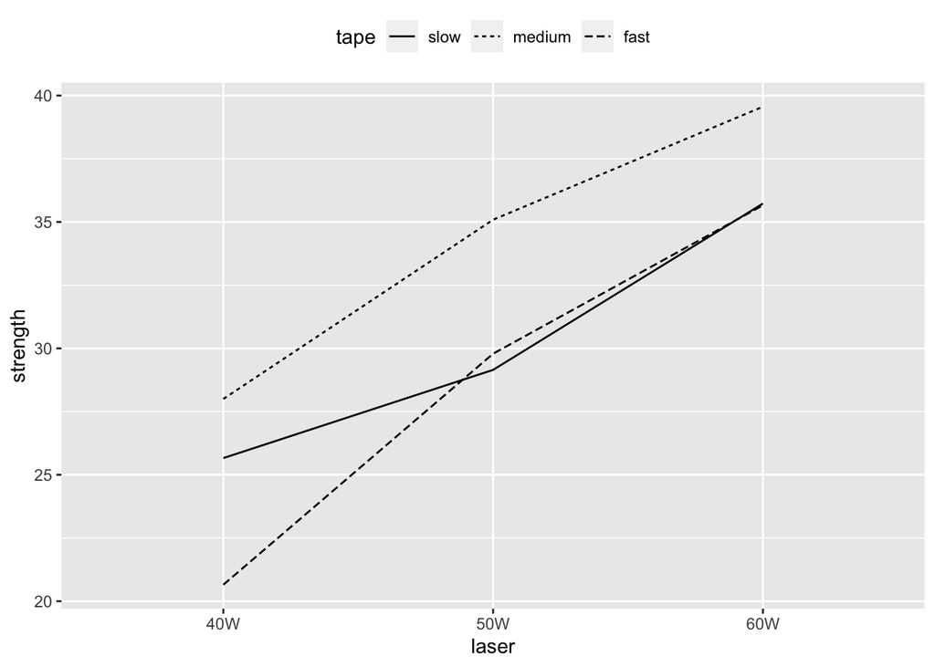

```r
ggplot(composite, aes(x=laser, y=strength, group=tape, linetype=tape))+
  geom_line() + theme(legend.position="top", legend.direction="horizontal")
```

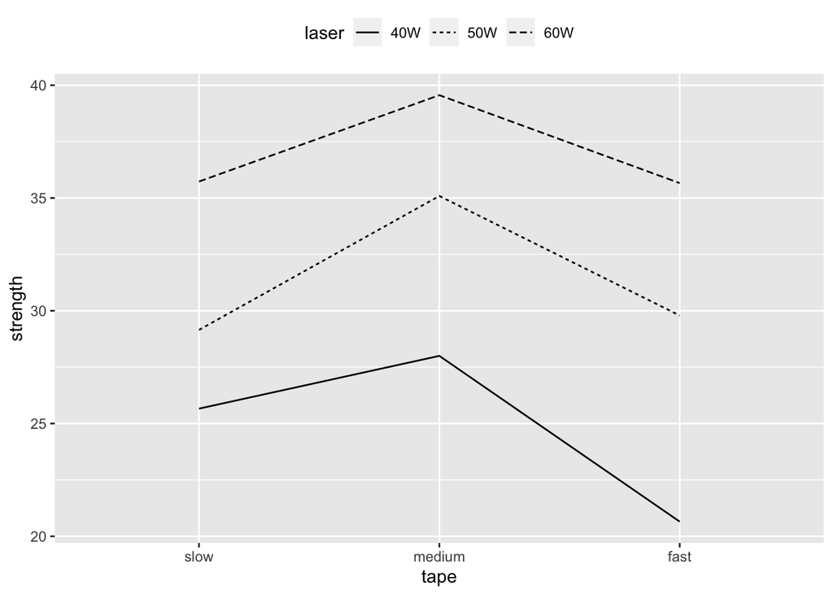

```r
ggplot(composite, aes(x=tape, y=strength, group=laser, linetype=laser))+
  geom_line() + theme(legend.position="top", legend.direction="horizontal")
```

Besed on these plots, we can see that interactions are present, but we still do not know whether they are statistically significant. In order to test for a special type of interactions, we have Tukey’s additivity test.

#### Tukey’s Test for Additivity

The steps to perform Tukey’s test for additivity are the following:

**1.** Fit the main effects model

```r
meffectmodel <- lm(strength ~ laser + tape, composite)
summary(meffectmodel)
```

```
##
## Call:
## lm(formula = strength ~ laser + tape, data = composite)
##
## Residuals:
##        1        2        3        4        5        6        7        8
##  1.74222 -1.34111 -0.40111  0.04556  0.56222 -0.60778 -1.78778  0.77889
##        9
##  1.00889
##
## Coefficients:
##             Estimate Std. Error t value Pr(>|t|)
## (Intercept)   23.918      1.208  19.803 3.84e-05 ***
## laser50W       6.573      1.323   4.968 0.007661 **
## laser60W      12.213      1.323   9.231 0.000765 ***
## tapemedium     4.037      1.323   3.051 0.037991 *
## tapefast      -1.480      1.323  -1.119 0.325944
## ---
## Signif. codes:  0 '***' 0.001 '**' 0.01 '*' 0.05 '.' 0.1 ' ' 1
##
## Residual standard error: 1.62 on 4 degrees of freedom
## Multiple R-squared:  0.963,  Adjusted R-squared:  0.9259
## F-statistic:    26 on 4 and 4 DF,  p-value: 0.004013
```

**2.** Extract the main effects estimates from no-interaction model

```r
lasercoefs <- rep(c(0, 6.5733, 12.2133), 3)
tapecoefs <- rep(c(0, 4.0367, -1.4800), each=3)
```

**3.** Update the model with the new predictor formula from the product of main effects

```r
newmod <- update(meffectmodel, .~. + I(lasercoefs*tapecoefs))
anova(newmod)
```

```
## Analysis of Variance Table
##
## Response: strength
##                           Df  Sum Sq Mean Sq F value   Pr(>F)
## laser                      2 224.184 112.092 36.8201 0.007745 **
## tape                       2  48.919  24.459  8.0344 0.062401 .
## I(lasercoefs * tapecoefs)  1   1.370   1.370  0.4501 0.550340
## Residuals                  3   9.133   3.044
## ---
## Signif. codes:  0 '***' 0.001 '**' 0.01 '*' 0.05 '.' 0.1 ' ' 1
```

```r
meffectmodel <- lm(strength ~ laser + tape, composite)
lasercoefs <- rep(c(0, 6.5733, 12.2133), 3)
tapecoefs <- rep(c(0, 4.0367, -1.4800), each=3)

newmod <- update(meffectmodel, .~. + I(lasercoefs*tapecoefs))
anova(newmod)
```

```
## Analysis of Variance Table
##
## Response: strength
##                           Df  Sum Sq Mean Sq F value   Pr(>F)
## laser                      2 224.184 112.092 36.8201 0.007745 **
## tape                       2  48.919  24.459  8.0344 0.062401 .
## I(lasercoefs * tapecoefs)  1   1.370   1.370  0.4501 0.550340
## Residuals                  3   9.133   3.044
## ---
## Signif. codes:  0 '***' 0.001 '**' 0.01 '*' 0.05 '.' 0.1 ' ' 1
```

An alternative way to do Tukey’s additivity test in R is the following:

```r
fitteda = meffectmodel$fitted.values
resida = meffectmodel$residuals

newmodel = lm(fitteda^2 ~ composite$laser + composite$tape)
newfitteda = newmodel$fitted.values

thetareg = lm(resida ~ newmodel$residuals)
summary(thetareg)
```

```
##
## Call:
## lm(formula = resida ~ newmodel$residuals)
##
## Residuals:
##      Min       1Q   Median       3Q      Max
## -1.35000 -0.62313  0.02769  0.59544  1.92118
##
## Coefficients:
##                      Estimate Std. Error t value Pr(>|t|)
## (Intercept)         6.409e-17  3.807e-01   0.000     1.00
## newmodel$residuals -1.677e-02  1.636e-02  -1.025     0.34
##
## Residual standard error: 1.142 on 7 degrees of freedom
## Multiple R-squared:  0.1304, Adjusted R-squared:  0.006227
## F-statistic:  1.05 on 1 and 7 DF,  p-value: 0.3396
```

```r
anova(thetareg)
```

```
## Analysis of Variance Table
##
## Response: resida
##                    Df Sum Sq Mean Sq F value Pr(>F)
## newmodel$residuals  1 1.3701  1.3701  1.0501 0.3396
## Residuals           7 9.1329  1.3047
```

```r
anova(meffectmodel, newmod)
```

```
## Analysis of Variance Table
##
## Model 1: strength ~ laser + tape
## Model 2: strength ~ laser + tape + I(lasercoefs * tapecoefs)
##   Res.Df     RSS Df Sum of Sq      F Pr(>F)
## 1      4 10.5030
## 2      3  9.1329  1    1.3701 0.4501 0.5503
```